# Exercise week 4

Nicolas Perez

November 2017

## Sampling from a normal distribution

$$X_i \sim \mathcal{N}(0,\,1)$$

```r
set.seed(116)
observations<-100
samples<-100
datasets<-replicate(samples,rnorm(observations,mean=0,sd=1))
```

## Summarizing the results

For every sampled $X_i$, we compute: 1) absolute bias, 2) standard error, 3) 95% CI Lower Bound and 4) 95% CI Upper bound.

For computing the measures of interest we use the following formulas

$$bias=|\bar{x}-\mu|$$
Since the population mean is $0$, then the absolute bias can be measured by the absolute value of the mean value of the $i$-th sample.

$$bias=|\bar{x}|$$
For the standard error we use the estimated standard deviation of the sample and we adjust by the square root of the number of observations

$$S.E=\hat{\sigma} / \sqrt{n}$$
Finally for the 95% Confidence Intervals, we use the 2.5% and 97.5% quantiles of the normal distribution (it can be shown that the sample mean follows such a distribution but is not part of this exercise) and we build the CI as:

$$CI_{95\%}= [\bar{x} - 1.96*S.E, \bar{x} + 1.96*S.E]$$

```r
results<-matrix(NA,nrow=5,ncol=samples)
results[1,]<-abs(colMeans(datasets)-0)
results[2,]<-apply(X=datasets,MARGIN=2,FUN=sd)/sqrt(observations)
results[3,]<-colMeans(datasets)+results[2,]*-1.96
results[4,]<-colMeans(datasets)+results[2,]*1.96
results[5,]<-ifelse((results[4,]<0 | results[3,]>0),1,0)
```

## Including Plots

We can make a plot of the Confidence Intervals containing the true population value for the mean, and given the definition of coverage probabilities for the CIs by Neyman, approximately we should encounter 95% of the CIs to contain the population value for the mean ($0$).

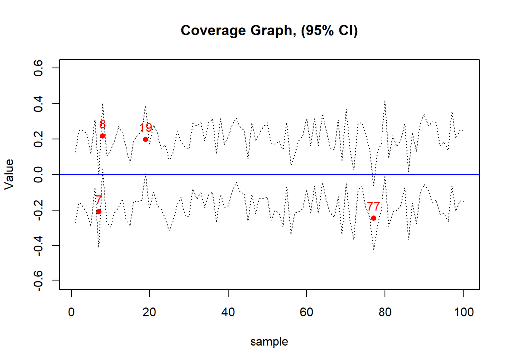

```r
plot(c(1:samples),results[3,],type="l", lty=3, ylim=c(-0.6,0.6), main="Coverage Graph, (95% CI)",
     xlab="sample", ylab="Value")
lines(c(1:samples),results[4,],type="l", lty=3)
abline(h=0, col="blue")
lines(which(results[5,]==1),colMeans(datasets[,results[5,]==1]), type="p", pch=16, col="red")
text(x=1:samples, y=0.07+colMeans(datasets), labels=ifelse(results[5,]==1,c(1:samples),""), col="red")
```

To create a table we only need to subsample the datasets that are plotted in the graph (already identified through a rule of being or not in the CIs when the results table was created).

```r
library(knitr)
dataNC<-data.frame(datasets[,results[5,]==1])
colnames(dataNC)<-paste("Sample ", which(results[5,]==1))
kable(dataNC, caption = "Simulated samples that don't cover the population mean")
```

Simulated samples that don’t cover the population mean

| Sample 7 | Sample 8 | Sample 19 | Sample 77 |
| --- | --- | --- | --- |
| 1.2517498 | 1.9692379 | -0.4529828 | -0.6490441 |
| -1.9903895 | 0.5873171 | -0.2817015 | -0.6160511 |
| 0.3045662 | -0.0453797 | -0.0905107 | 0.3551798 |
| -0.1858447 | 1.4307386 | -1.4532170 | 0.2491681 |
| -1.3600289 | -1.0134279 | 1.6172675 | 0.2865814 |
| 2.7265490 | -0.3736479 | 0.8980978 | -1.6043817 |
| 1.7501407 | 1.1647646 | 1.8605523 | -1.3762765 |
| 0.1463708 | 1.3314699 | 0.6210840 | -0.1715358 |
| -1.5889296 | -0.0929175 | 0.2062418 | -0.3953302 |
| -1.2120707 | 0.1862358 | -1.1378550 | 0.0477547 |
| -1.5159709 | -1.0052533 | 1.0410470 | -0.9658773 |
| -1.0943875 | -0.5559941 | -1.0181130 | -0.6999948 |
| -0.0534888 | -0.0337766 | 0.9377893 | -0.9576130 |
| 1.0382069 | -1.1917551 | -0.1045848 | 0.7376397 |
| 1.3874429 | 0.0344291 | 0.1141356 | 0.1070966 |
| -1.2372392 | 0.2637932 | -0.7017393 | -0.4801000 |
| -2.5143227 | 0.4391892 | 0.3013669 | 0.0464895 |
| -0.9604771 | 1.6224355 | -0.0651412 | 0.4861123 |
| 0.9310120 | 0.9614888 | 0.0771221 | -0.2524342 |
| 1.0951465 | 0.0046869 | -0.6870293 | 0.9476420 |
| -1.0890875 | -0.0077011 | 1.1614215 | -0.7524943 |
| -0.3520838 | 0.6689424 | 0.5820993 | 1.1255018 |
| 0.0303478 | 0.2767819 | 0.7700043 | -1.0895348 |
| -0.0287062 | -0.3261488 | 1.5865285 | 0.5310555 |
| -0.3855384 | 0.1271549 | 0.7656497 | 0.3697698 |
| -0.4960715 | 2.0227722 | -0.6912451 | 0.3540885 |
| 1.8040859 | -0.6057704 | -0.6089610 | 0.4928349 |
| 0.8484951 | 0.8219426 | -0.0968064 | -0.2778967 |
| 0.8751577 | 0.2156844 | -1.6252786 | -0.5962989 |
| -0.7226689 | -0.6735259 | -0.9406554 | -0.7354138 |

[output cut: 70 more lines]